# Example NFCN2

D.H. Heiland

7/29/2021

## Background

In recent years, several algorithms have been developed to infer cellular connections from receptor ligand expression profiles, allowing the prediction of potential interactions from single-cell transcriptomic data. The best known algorithms are CellPhoneDB and CellChat, two R-based pipelines. Both algorithms are based on previously annotated clusters and use the resulting cell groups to infer connectivity. These algorithms are both highly recommended for de novo exploration of data, but are imprecise when defined signaling pathways across cell populations are required. In our study, we aimed to develop an unsupervised algorithm that predicts the cellular interactions of a target and source population without prior cluster annotations. The new version of the NFCN algorithm (NFCN2) is tailored to predict cell pairs that are likely to be connected. Integration of spatially resolved transcriptomics and PIC-seq (doublets) is used to further correct predicted cell-cell interactions. The algorithms can be seen as complementary to CellPhoneDB and CellChat, where the determined cell-cell interactions are further validated. In the current version, we implemented CellChat as the first step of the algorithm, which opens the possibility to combine de novo exploration and validation within the NFCN pipeline. For user-friendly data integration, we used the Seurat object as a common S4 object format. The analysis results are stored as “assay” in the object.

To set up and install NFCN2:: please also install Seurat and SPATA2 as requirements.

## Data Import

Load scRNA-seq data and spatial transcriptomics (optinal). Here, we use a scRNA-seq dataset of GBM-associated myeloid/T cells and stRNA-seq of GBM. Based on private analysis, the question is to what extent myeloid cells contribute to TGFb response in T cells. The input dataset of scRNA-seq is a Seurat object and the stRNA-seq is formatted as SPATA-obj. We also need a target definition (vector with characters defining the cluster/cell type affected by the cell-cell contact) and a source definition.

```r
object
```

```
## An object of class Seurat
## 54423 features across 37616 samples within 4 assays
## Active assay: SCT (26615 features, 3000 variable features)
##  3 other assays present: RNA, prediction.score.celltype.l2, predicted_ADT
##  5 dimensional reductions calculated: mnn, umap, pca, ref.spca, ref.umap
```

```r
spata.obj <- spata.ob.S5

target
```

```
##  [1] "CD4_7"  "CD4_13" "CD4_3"  "CD4_6"  "CD4_0"  "CD4_10" "CD4_4"  "CD4_16" "CD4_2"  "CD4_5"  "CD4_1"  "CD4_18" "CD4_8"  "CD4_11" "CD4_17" "CD8_2"  "CD8_0"
## [18] "CD8_3"  "CD8_4"  "CD8_5"  "CD8_1"
```

```r
source
```

```
## [1] "aM1"    "aM2"    "microM" "moM"    "Mono"   "cDC2"   "prolif" "cDC2"
```

## Baseline Analysis and Model fitting

NFCN2 works Seurat objects. All data will be stored in the Seurat object as a new assay named NFCN. To set up the slot, we run NFCN2::createSlotNFCN and define the source and target pulses. We then identify the connected downstream and upstream gene sets and calculate the signal enrichment. To check which signal paths are supported, you can call the function:

```r
CellChat::CellChatDB.human$interaction$pathway_name %>% unique() %>%  head(20)
```

```
##  [1] "TGFb"    "BMP"     "BMP10"   "GDF"     "MSTN"    "AMH"     "GDNF"    "NODAL"   "ACTIVIN" "WNT"     "ncWNT"   "EGF"     "NRG"     "FGF"     "PDGF"
## [16] "VEGF"    "IGF"     "INSULIN" "APELIN"  "HH"
```

The NFCN2::inferConnectedPathways function is connected to the CellChatDB.human database to call the receptor-ligand pairs and the corresponding downstream pathways via SPATA2. Finally, the NFCN model is fitted. The model span needs to be tailored to your dataset.

```r
object <- NFCN2::createSlotNFCN(object,target=target, source=source)
object <- NFCN2::inferConnectedPathways(object, pathway = "TGFb")
```

```
## ## 1/4 Set up soure up-stream
```

```
## ## 2/4 Set up soure down-stream
```

```
## ## 3/4 Infer scores for up- and downstream activation
```

```
## 18:43:23 Setting up new spata-object.
```

```
## 18:43:49 Active expression matrix set to 'scaled'.
```

```
## ## 4/4 Prepare data
```

## Plot NFCN Model

The model is presented as a scatter plot with the left side representing the ligand group and the right side representing the receptor cells, which are predefined as target and source sets. The y-axis illustrates downstream/upstream activation and the x-axis illustrates ligand/receptor expression. Only when both upstream and downstream activation and ligand/receptor expression are sufficient is a cell defined as connected. The model calculates the most likely connected cells in the source and target populations.

```
## Start Fitting the Model by using sc_RNAseq Data
```

```
## ## 1/3  Fitting Receptor
```

```
## ## 2/3  Fitting Ligand
```

```
## ## 3/3  Fitting Model
```

```
## ## Quantify NFCN's
```

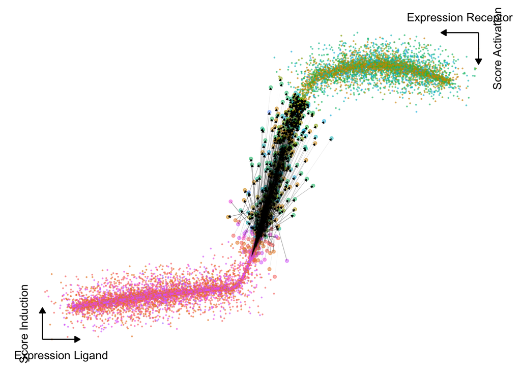

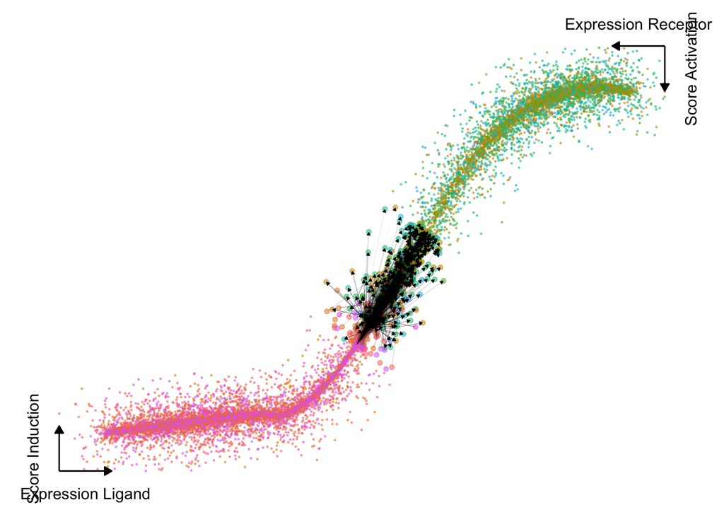

```r
object <- NFCN2::inferNFCN(object, model.span = 0.8)
NFCN2::plotNFCN(object)
```

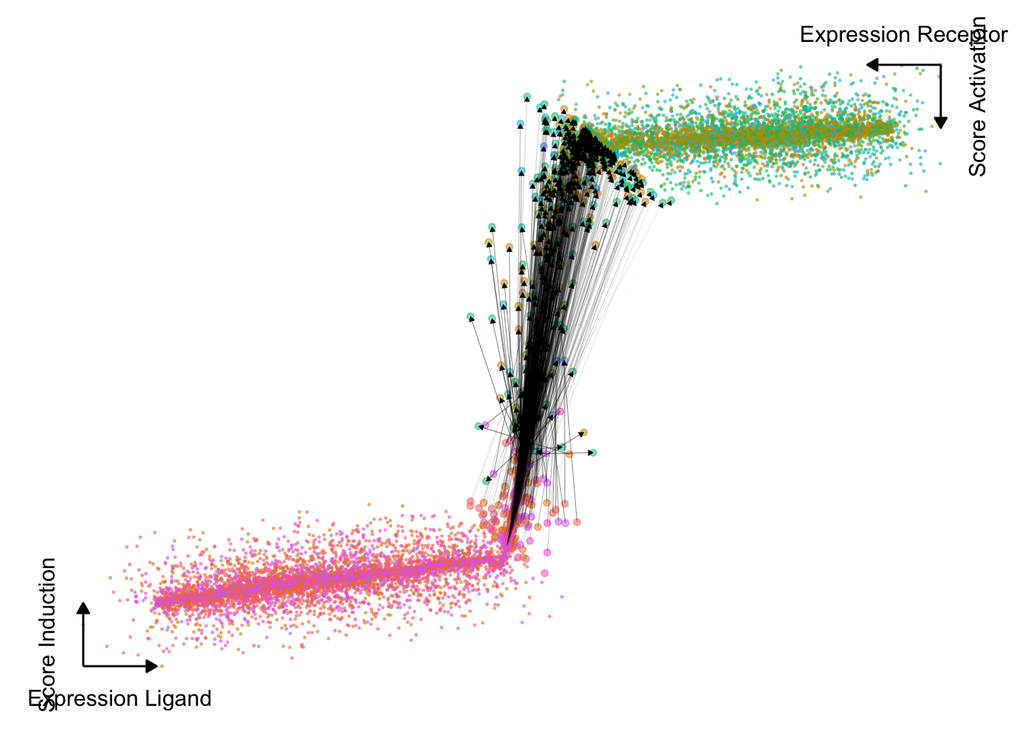

```r
object <- NFCN2::inferNFCN(object, model.span = 0.1)
NFCN2::plotNFCN(object)
```

We can also show the connections in the umap of the seurat object.

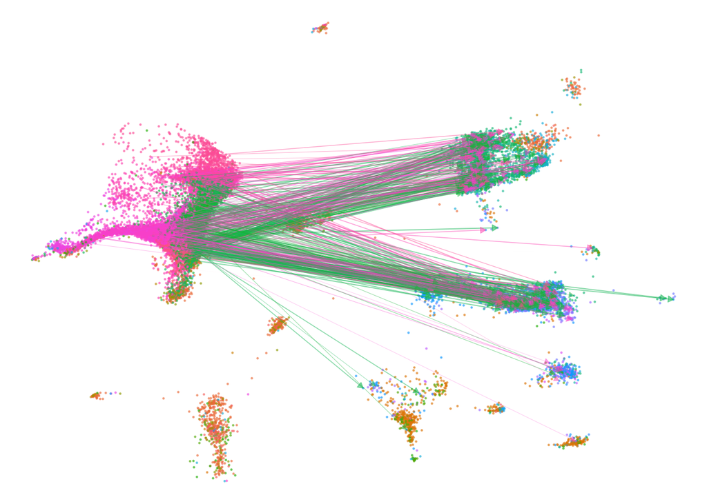

```r
NFCN2::plotNFCNDimRed(object)
```

## Correction of NFCN by stRNA-seq integration

Since, the NFCN model lack of spatial validation, we implemented a correction of the most likely cell pairs using the stRNA-seq data. In a first step, we infer the putativ distance of our connected cells.

```r
future::plan("multiprocess", workers = 1)
inferSpatialPosition.object <- NFCN2::inferSpatialPosition(object, spata.obj)
```

In the next step, we correct for juxtaposition pobability. The distance can be changed based on the type of spatial data (IMC/Visium or others)

```r
object <- NFCN2::inferSpatialCorrection(object,
                                        inferSpatialPosition.object,
                                        assay="SCT",
                                        estimator=1, nr.genes=20)

#Correct the spatial probabilities by max distance

inferSpatialPosition.object <- NFCN2::inferSpatialPosition(object,
                                                           spata.obj,
                                                           correction.distance = 100)
```

We can explore the infered relationships across clusters or cell types:

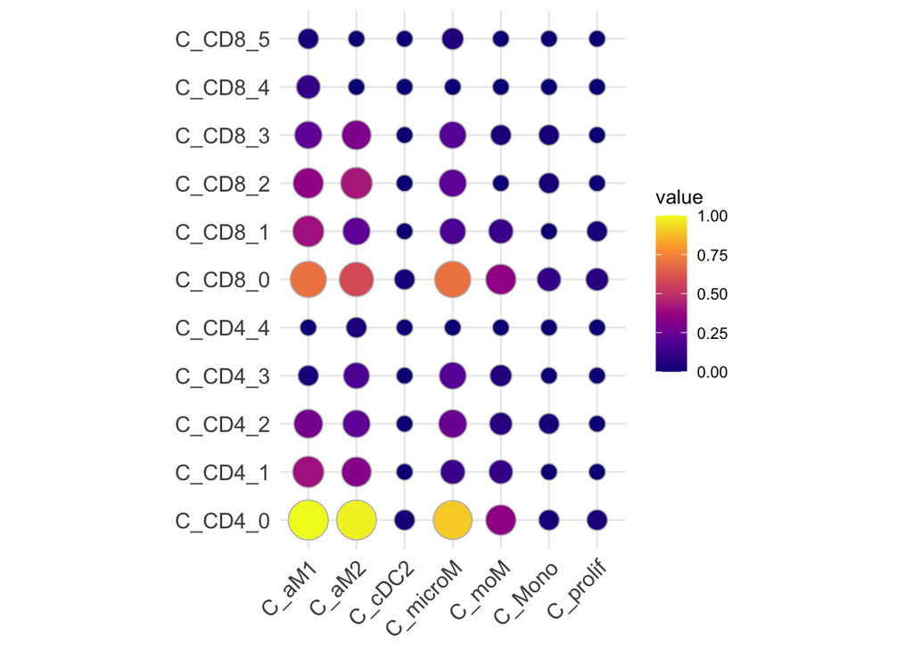

```r
NFCN2::plotNFCNDotplot(object)
```

Functional enrichment of the connected cells:

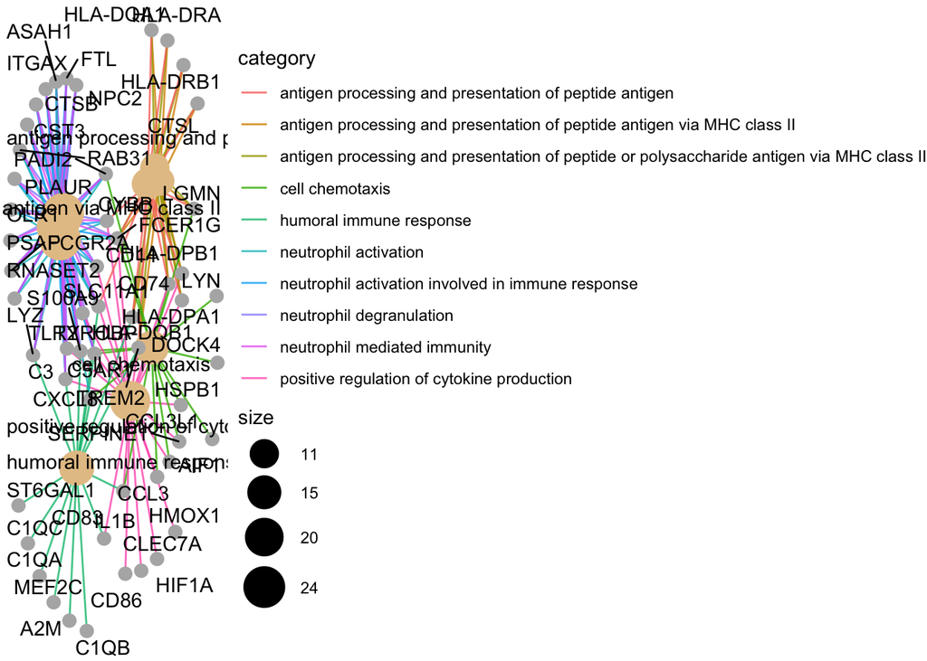

```r
functional <- NFCN2::findFunctionalEnrichment(inferSpatialPosition.object$marker$connected)
clusterProfiler::cnetplot(functional[[1]], showCategory = 10, colorEdge = TRUE)
```